# 경찰 피복류 최적 치수체계 도입을 위한 데이터 분석

데이터정책팀 박승규 경감

2023-06-09

## 1. 개관

### 1.1. 분석의 배경

- (현황) 현재 경찰 피복류 제작 및 지급은 (1)체촌 $\rightarrow$ (2)제작 $\rightarrow$ (3)지급 $\rightarrow$ (4)수선의뢰 $\rightarrow$ (5)수선 및 지급 順 단계를 걸쳐 진행
- (장점) 개개인의 치수 특성에 최대한 맞는 피복을 제작, 맞지 않는 부분은 수선이 가능하다는 장점이 있으나
- (단점) 시일이 지나치게 오래 걸리고, 맞춤 방식이 아니라 업체 고유의 치수체계에서 개인의 치수에 가장 적합한 사이즈를 골라서 제작하는 방식으로 피복 맞춤도에 대한 불만이 상존
- 현재의 피복 제작 체계의 대안으로 피복치수제를 도입한다면, 어떤 치수체계를 적용하는 것이 가장 효율적일지에 대한 판단 자료가 필요

**(참고자료) 옷 제작 방식의 종류**(클릭하세요)**

##### 비스포크(완전수제)

세세하게 신체 각 부분의 치수를 재고 최초의 옷 틀(패턴)부터 맞춤으로 수제작하는 방식

##### MTM(반수제)

주요 사이즈별로 대략적인 옷 틀을 정해놓고 주문에 따라 원단, 세부 사이즈 및 디자인을 다르게 하여 제작하는 방식

##### 시스템오더

원단과 사이즈를 소매점 또는 대리점에서 주문 접수 후 본사로 전달, 공장에서 소량생산 방식으로 제작하는 방식

##### 기성복

고유한 치수체계에 따라 옷을 사전 제작하고 해당 치수체계에 맞는 사이즈를 선택하여 지급하는 방식

##### 현재 경찰 피복 제작 방식은?

기성복 제작과 시스템오더를 혼합한 방식으로, 피복 제작업체의 고유한 치수체계 하에 개인별로 사이즈를 정해 옷을 제작하고 바지기장, 소매, 허리를 일부 조정하여 완성

### 1.2. 분석의 목적

- 본 과제는 다음의 질문에 대한 답을 얻기 위해 진행함(의뢰부서 : 장비과[장비정책계])
- 1. 기성복 형식으로 경찰관 피복을 제작한다고 가정했을 때 치수체계를 어떻게 설정해야 하는가?
- 2. 현행의 치수체계, 의류업계에서 광범위하게 사용하는 표준 치수체계와 다른 치수체계를 도입할 필요가 있는가?

### 1.3. 용어의 정의

- 치수체계 : 의류의 사이즈(호수)별로 정해진 신체 부위(상의 : 목, 가슴, 어깨, 소매기장, 허리, 등, 하의 : 허리, 엉덩이(힢), 다리기장)별 치수를 정해놓은 표<sup>[1]</sup>
- 피트<sup>[2]</sup> : 옷이 몸에 맞는 정도를 나타내는 용어. “피트성이 있다”는 옷이 몸에 맞춰서 많이 달라붙는다는 뜻으로, 정복 바지, 근무복 상하의가 피트성이 있는 옷에 해당. 반면, “피트성이 없다”는 옷이 몸에 붙지 않고 느슨하다는 뜻으로, 기동복 상하의, 외투류 운동복 등이 피트성이 없는 옷에 해당.
- 신체 각 부위별 치수의 측정방법

| 명칭 | 내용 |
| --- | --- |
| 가슴 | 겨드랑이 바로 아래를 중심으로 둘레를 측정 |
| 어깨 | 양쪽 어깨뼈 끝점과 목 뒤쪽을 연결한 유선형태로 측정 |
| 목 | 쇄골 아래 파인 지점을 중심으로 물방울 모양으로 둘레를 측정 |
| 소매기장 | 목 뒤쪽-어깨뼈 끝점-소매를 연결하는 길이를 측정 |
| 허리 | 골반뼈 위 허리 부분의 둘레를 측정 |
| 총장<sup>[3]</sup> | 목 뒤쪽에서 발목에 이르는 길이를 측정(경찰 체촌업체 사용 치수) |
| 힢 | 엉덩이 최대 둘레를 측정 |
| 다리기장 | 허리에서 발목까지의 길이를 측정 |

[1] 본 분석에서는 경찰 체촌 데이터에 맞춰 상의는 [목, 가슴, 어깨, 소매, 허리, 등], 하의는 [허리, 힢, 다리]를 기준으로 치수체계를 구성함

[2] 본 분석에서는 피트성이 있는 옷을 **슬림형**, 피트성이 없는 옷을 **일반형**으로 지칭

[3] 통상 기성복 치수체계에서는 키에 일정 비율을 곱해서 대용 치수로 사용

**치수체계 예시(클릭하세요)**

| 치수체계 예시 | 가슴 | 키 | 허리 | 힢 | 등 | 어깨 | 팔 |
| --- | --- | --- | --- | --- | --- | --- | --- |
| 95호 | 95 | 169.7 | 81.9 | 93.9 | 42.3 | 42.9 | 57.5 |
| 100호 | 100 | 170.8 | 86.4 | 97.1 | 42.7 | 43.7 | 58 |
| 105호 | 105 | 171.6 | 91.3 | 100.1 | 43 | 44.9 | 58.5 |

**(참고자료) 의류 제작과정**(클릭하세요)**

##### 개관

의류는 (1) 옷본 만들기, (2) 옷본에 따라 재단, (3) 봉재 순서로 제작. 옷 사이즈를 결정하는 데에 가장 영향을 많이 미치는 단계는 (1) 옷본 만들기 단계로, 상의와 하의의 순서가 다름

##### 상의 옷본

1. 가슴둘레(가로) $\times$ 등(세로) 크기의 직사각형 도안
2. 어깨, 목, 허리 사이즈에 맞춰 윤곽 설정
3. 1~2의 과정을 앞판, 뒷판 별도로 작업
4. 소매 길이에 맞춰 소매 옷본을 별도로 도안
5. 주머니, 주름 등 기타 세부 사항에 맞춰서 도안 수정

##### 하의 옷본

1. 허리둘레(가로) $\times$ 다리기장(세로) 크기의 직사각형 도안
2. 엉덩이 사이즈에 맞춰 윤곽 설정
3. 주머니, 주름 등 기타 세부 사항에 맞춰서 도안 수정

### 1.4. 분석 기본 정보

- 수행기간 : 2023. 4. 17. ~ 6.9.(8주간)
- 사용 데이터 : 2022년 전국 경찰관 체촌 데이터(85,159건, 미도물산), 제8차 한국인 인체치수조사 데이터(2020~21년, 국가기술표준원), 성인 남성복/여성복 치수 국가표준(2019년, 국가기술표준원)
- 분석도구 : R(체촌 데이터 탐색, 치수체계 도출, 평가점수 계산), 태블로(경찰관 체촌 데이터 시각화), Shiny(치수체계 제작 및 평가용 앱 구현)

## 2. 데이터 탐색

- 경찰관의 인체 치수 데이터는 한국인 인체 치수 데이터와 비교했을 때에 통계적으로 유의미한 차이를 보이고 있음
- 남성은 목을 제외한 모든 치수가 한국인 평균보다 크고, 특히 엉덩이, 어깨, 가슴 사이즈가 평균 대비 3~7 센티미터 큼
- 여성은 목과 허리를 제외한 치수가 한국인 평균보다 크고, 특히 다리, 엉덩이, 총장 사이즈가 평균 대비 3~4 센티미터 큼

### 2.1. 국민 치수 데이터와 경찰 치수 데이터의 분포 비교

- 남성 데이터 비교(녹색은 경찰관 치수 분포)

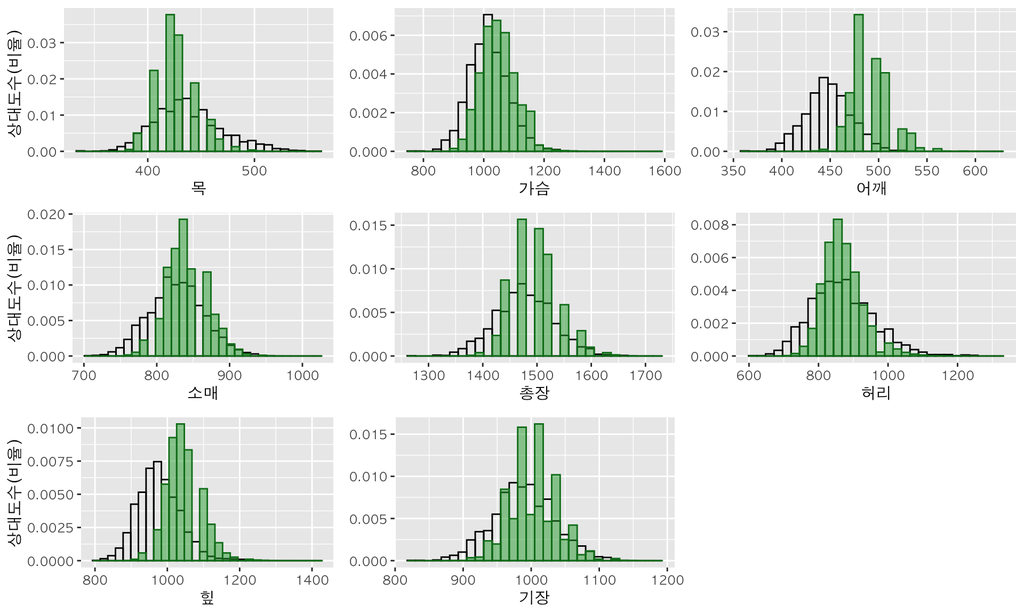

- 여성 데이터 비교(녹색은 경찰관 치수 분포)

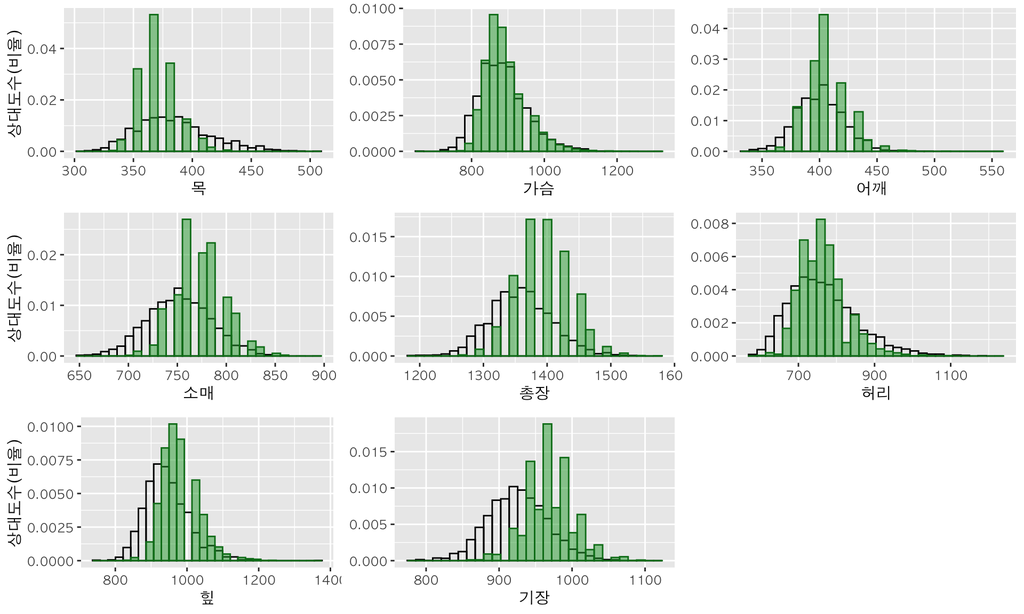

### 2.2. 국민 치수 데이터와 경찰 치수 데이터의 대표값(평균) 비교

- 국민 치수 데이터 평균(굵은 세로선)을 중심으로 경찰 치수가 작은 경우 왼쪽, 큰 경우 오른쪽에 표시

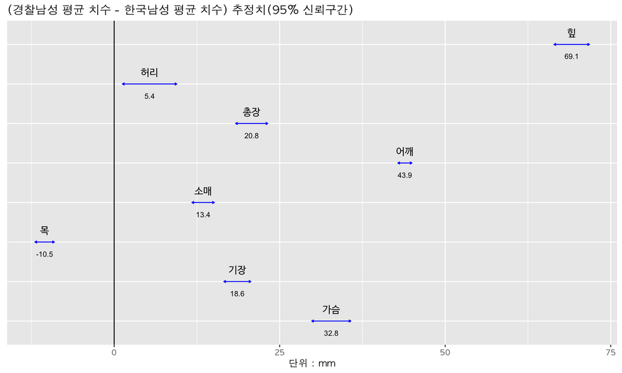

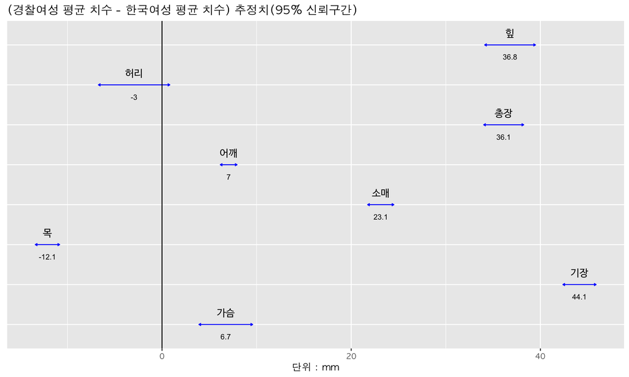

### 2.3. 주성분분석

- (개요) 주성분분석이란 여러 개의 변수 간 관계를 찾아내기 위해 수행하는 비지도학습 분석 방법 중 하나로
- (목적) 치수체계를 구성하는 여러 치수의 관계를 확인하고 어느 신체부위 치수를 중심으로 치수를 결정하는 것이 좋을지 확인하기 위해서 주성분분석 수행
- 국민 치수 데이터(총 137개 부위별 측정)를 중심으로 하는 주성분분석에서는 수평 요인(가슴둘레, 허리둘레, 어깨너비 등)과 수직요인(키, 소매기장, 다리기장 등) 간 연관성이 깊은 것으로 알려짐
- 경찰 체촌 데이터를 이용하여 주성분분석한 결과, 국민 치수 데이터와 마찬가지로 수평요인(가슴, 허리, 힢, 어깨)과 수직요인(소매, 다리, 총장)으로 나누어 볼 수 있는 것으로 확인
- 따라서, 상의는 가슴(수평)과 소매(수직), 하의는 허리(수평)와 다리(수직) 분배가 치수체계 구성의 핵심 요소라고 할 수 있음

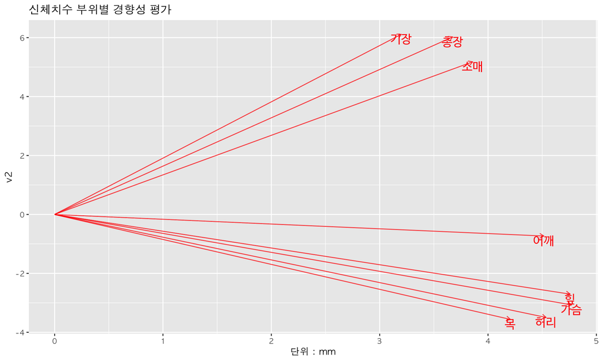

### 2.4. 경찰 체촌 데이터 신체부위별 분포

- 경찰 체촌 데이터를 각 부위별 분포를 확인한 결과, 주성분분석과 일맥상통하게 수평요인 간에는 상관성이 높고 수평요인과 수직요인 간에는 상관성이 높지 않은 것으로 나타남
- 특히, 소매기장과 다리기장은 수평요인과 비교했을 때에 지나치게 상관성이 낮은 분포를 보이고 있어서, **소매기장과 다리기장 구성이 피복 치수 만족도를 좌우할 수 있는 핵심 요소임을 시사**

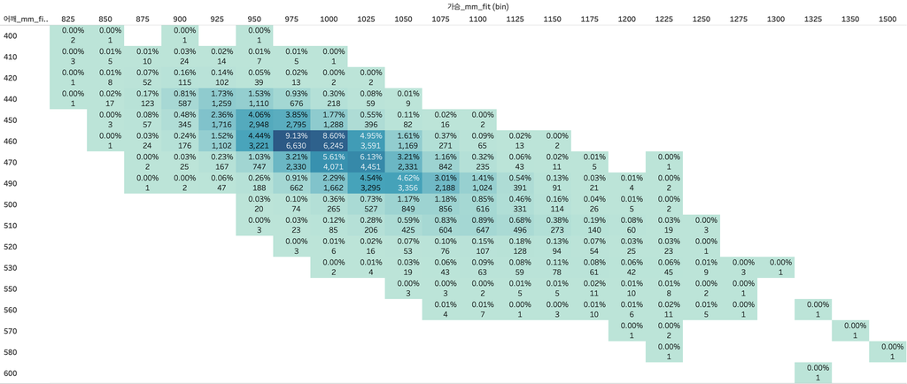

남성상의 치수 분포(가슴-어깨)

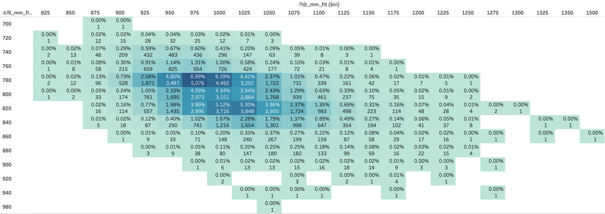

남성상의 치수 분포(가슴-소매)

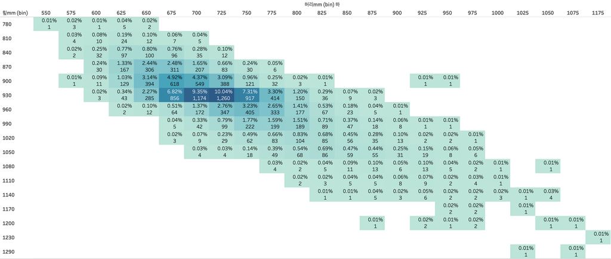

여성하의 치수 분포(허리-엉덩이)

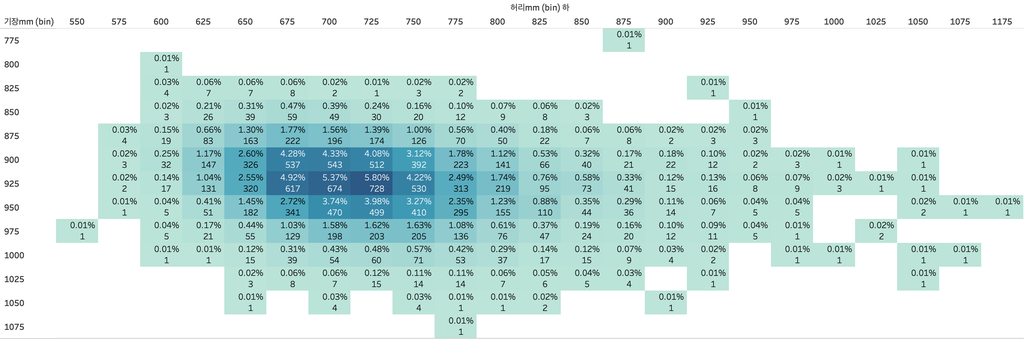

여성하의 치수 분포(허리-다리기장)

## 3. 분석

- 치수체계 고안 및 비교를 위해 (1) 수리적 데이터 분석에 기반한 치수체계, (2) KS 국가표준 치수체계에 기반한 치수체계, (3) 기존 경찰 피복 치수체계 세 가지 방법으로 치수체계를 만들고,
- 각 치수체계를 경찰 체촌 데이터를 이용하여 적합도 평가, 점수에 따라 최적 치수체계를 산출

### 3.1. 치수체계 구현

#### 3.1.1. 데이터 분석에 기반한 치수체계

- 의뢰부서(장비과)에서 구상하고 있는 치수체계 구성방안(상의 치수 7종/옵션 4종, 하의 치수 10종/옵션 2종)에 맞춰 최적의 치수체계를 수리적으로 계산하여 산출
- 데이터를 이용하여 유사성이 높은 그룹을 묶는 군집분석$^*$을 진행, 군집화의 기준이 되는 데이터와 군집화 방법에 따라 총 8종류의 치수체계를 도출
- 군집화 모형 요약

| 이름 | 군집화 방법 | 군집화 기준 데이터 |
| --- | --- | --- |
| KM1 | K평균 군집 | 국민치수 주성분 1개 |
| HC2 | 위계적 군집 | 국민치수 주성분 1개 |
| KM3 | K평균 군집 | 경찰치수 주성분 1개(상하의 통합) |
| HC4 | 위계적 군집 | 경찰치수 주성분 1개(상하의 통합) |
| KM5 | K평균 군집 | 경찰치수 원데이터 9종(상하의 구분) |
| HC6 | 위계적 군집 | 경찰치수 원데이터 9종(상하의 구분) |
| KM7 | K평균 군집 | 경찰치수 주성분 2개(상하의 구분) |
| HC8 | 위계적 군집 | 경찰치수 주성분 2개(상하의 구분) |

**(참고자료) 군집분석**(클릭하세요)**

##### 군집분석이란?

여러 개의 데이터를 유사성이 높은 그룹으로 묶는 비지도학습 방법의 데이터 분석 방법. 데이터값을 기준으로 군집 내 유사도를 극대화하고 군집 간 유사도를 극소화하는 방식으로 군집화가 이루어진다.

##### 군집화의 기준이 되는 데이터

군집화를 위해 원 데이터를 가공하지 않고 이용하기도 하고, 원 데이터의 변수가 너무 많아서 수리적 계산이 복잡해지는 경우 주성분분석을 통해 변수의 수를 줄여서 군집화가 이루어지기도 함.

##### 군집화 방법

군집화 방법에는 위계적 군집화(개별 데이터 하나하나의 거리를 전부 측정하여 가까운 순서대로 군집화), 확률적 군집화(특정 기준점에서 거리를 기준으로 군집화), 분포기반 군집화(전체 데이터의 분포를 추정하여 군집화) 등 방법이 있다. 본 분석에서는 데이터의 특성을 감안하여 위계적 군집화와 확률적 군집화(K평균 군집) 방법으로 치수체계를 구성하였다.

#### 3.1.2. 대조 치수체계1 : KS 표준체계

- 국가표준원에서 제시한 KS 표준체계(남성복 KS K 0050, 여성복 KS K 0051)를 경찰관 체촌 데이터와 결합하여 별도로 구성한 치수체계
- 기존 KS 표준체계는 2005년 국민 치수조사 결과를 바탕으로 구성, 그동안 국민 치수조사 분포가 달라져 표준체계를 그대로 사용할 경우 지나치게 사이즈가 작은 문제 발생
- 표준체계에서 제시하는 치수 종류 중에서 경찰관 체촌 데이터 분포에 맞는 치수(상의 21종, 하의 30종)를 골라 별도의 치수체계로 구성

#### 3.1.3. 대조 치수체계2 : 현행 치수체계

- 금년 해경에서 도입한 치수 체계를 중심으로 현행 경찰 피복 제조업체(미도)의 제작방식을 참조하여 구성
- 슬림형 피복은 긴팔 근무복 상/하의 치수체계, 일반형 피복은 긴팔 기동복 상/하의 치수체계를 이용
- 현행 치수체계

| 피트 | 구분 | 피복 종류 | 호수 개수 | 옵션 종류 | 옵션 개수 |
| --- | --- | --- | --- | --- | --- |
| 슬림형 | 남성상의 | 긴팔 근무복 | 7종(90~120호) | 소매 | 4종(S/M/L/LL) |
| 슬림형 | 남성하의 | 근무복 바지 | 16종(29~44호) | 없음 |  |
| 슬림형 | 여성상의 | 긴팔 근무복 | 6종(44~99호) | 소매 | 4종(S/M/L/LL) |
| 슬림형 | 여성하의 | 근무복 바지 | 14종(27~40호) | 없음 |  |
| 일반형 | 남성상의 | 긴팔 기동복 | 7종(90~120호) | 소매 | 4종(S/M/L/LL) |
| 일반형 | 남성하의 | 기동복 하의 | 16종(29~44호) | 없음 |  |
| 일반형 | 여성상의 | 긴팔 기동복 | 6종(44~99호) | 소매 | 4종(S/M/L/LL) |
| 일반형 | 여성하의 | 기동복 하의 | 13종(26~38호) | 없음 |  |

### 3.2. 치수체계 평가

- 각 치수체계를 경찰관 체촌 데이터를 바탕으로 평가하여 점수화
- (1) 각 개인별 호수 선택, (2) 각 개인별 점수 산정, (3) 전체 평가 점수 합산/평균 순서로 각 치수체계의 종합 평가점수 계산

**(참고자료) 평가 방법 단계별 설명**

##### 1단계 : 개인별 호수 선택

각 개인별로 치수 기준 신체부위(상의 - 가슴/소매, 하의 - 허리/다리)에 따라 어떤 호수를 배정할 것인지를 선택

##### 2단계 : 개인별 점수 계산

1. 개인별로 배정된 호수의 세부 치수와 각 개인의 신체 치수를 비교하여 개인의 신체 치수가 호수의 세부 치수 오차 범위 안에 들어갈 경우(슬림형 1.5센티미터, 일반형 2.5센티미터) 1점, 들어가지 않을 경우 0점을 부여하고,
2. 신체 부위별 점수를 합산하여 개인별 전체 평가점수를 계산(상의 5점 만점, 하의 3점 만점)
3. 옵션이 있는 경우(상의 : 소매, 허리 / 하의 : 다리기장) 오차 범위의 2배 안에 들어갈 경우 1점, 들어가지 않을 경우 0점을 부여
4. 이때, 현행 치수체계 하에서는 개인별 체촌 결과에 따라 바지 기장 길이를 개인별 재단하는 방식으로 제작하기 때문에 바지 기장 점수는 모두 맞는 것으로 가정하고 점수 계산

##### 3단계 : 전체 평가점수 합산/평균

1단계와 2단계를 거친 전체 인원의 평가점수를 평균화하여 치수체계의 종합 평가점수로 산정

#### 3.3. 평가 결과

##### 3.3.1. 슬림형(피트성이 있는 옷)

남성상의 평가점수표

|  | KM1 | HC2 | KM3 | HC4 | KM5 | HC6 | KM7 | HC8 | KS | Pol |
| --- | --- | --- | --- | --- | --- | --- | --- | --- | --- | --- |
| 합계(원치수) | 3.07 | 2.86 | **3.09** | 2.92 | 2.98 | 2.52 | 2.92 | 2.10 | 2.44 | 1.67 |
| 합계(옵션포함) | 3.58 | 3.42 | **3.61** | 3.51 | 3.60 | 3.16 | 3.49 | 2.72 | 2.88 | 2.09 |
| 목 | 0.69 | 0.67 | 0.71 | 0.81 | 0.77 | 0.70 | 0.70 | 0.58 | 0.61 | 0.38 |
| 가슴 | 0.81 | 0.62 | 0.84 | 0.50 | 0.50 | 0.41 | 0.51 | 0.24 | 0.74 | 0.47 |
| 어깨 | 0.77 | 0.73 | 0.76 | 0.82 | 0.79 | 0.67 | 0.82 | 0.55 | 0.54 | 0.13 |
| 소매 | 0.49 | 0.48 | 0.49 | 0.51 | 0.64 | 0.43 | 0.58 | 0.52 | 0.17 | 0.34 |
| 허리 | 0.30 | 0.36 | 0.30 | 0.27 | 0.28 | 0.32 | 0.31 | 0.22 | 0.38 | 0.35 |
| 소매(옵션포함) | 0.75 | 0.80 | 0.75 | 0.81 | 0.95 | 0.80 | 0.89 | 0.81 | 0.44 | 0.65 |
| 허리(옵션포함) | 0.56 | 0.60 | 0.56 | 0.57 | 0.60 | 0.58 | 0.56 | 0.54 | 0.56 | 0.46 |

남성하의 평가점수표

|  | KM1 | HC2 | KM3 | HC4 | KM5 | HC6 | KM7 | HC8 | KS | Pol |
| --- | --- | --- | --- | --- | --- | --- | --- | --- | --- | --- |
| 합계(원치수) | 1.62 | 1.61 | 1.70 | 1.45 | 1.61 | 1.10 | 1.60 | 1.38 | 1.43 | **2.55** |
| 합계(옵션포함) | 1.87 | 1.82 | 1.96 | 1.70 | 1.82 | 1.25 | 1.82 | 1.65 | 1.74 | **2.55** |
| 허리 | 0.64 | 0.61 | 0.65 | 0.54 | 0.69 | 0.51 | 0.69 | 0.47 | 0.92 | 1.00 |
| 힢 | 0.66 | 0.65 | 0.70 | 0.56 | 0.65 | 0.45 | 0.64 | 0.68 | 0.35 | 0.55 |
| 기장 | 0.32 | 0.36 | 0.34 | 0.35 | 0.27 | 0.14 | 0.28 | 0.24 | 0.15 | 1.00 |
| 기장(옵션포함) | 0.58 | 0.56 | 0.60 | 0.60 | 0.48 | 0.29 | 0.50 | 0.50 | 0.46 | 1.00 |

여성상의 평가점수표

|  | KM1 | HC2 | KM3 | HC4 | KM5 | HC6 | KM7 | HC8 | KS | Pol |
| --- | --- | --- | --- | --- | --- | --- | --- | --- | --- | --- |
| 합계(원치수) | 3.05 | 2.67 | 3.01 | 2.75 | **3.19** | 2.51 | 2.96 | 2.30 | 2.69 | 2.03 |
| 합계(옵션포함) | 3.55 | 3.29 | 3.55 | 3.26 | **3.64** | 3.02 | 3.54 | 2.87 | 3.26 | 2.71 |
| 목 | 0.85 | 0.77 | 0.86 | 0.78 | 0.81 | 0.69 | 0.81 | 0.73 | 0.63 | 0.80 |
| 가슴 | 0.63 | 0.44 | 0.59 | 0.46 | 0.55 | 0.27 | 0.61 | 0.28 | 0.92 | 0.24 |
| 어깨 | 0.75 | 0.75 | 0.75 | 0.68 | 0.82 | 0.76 | 0.77 | 0.70 | 0.64 | 0.41 |
| 소매 | 0.48 | 0.40 | 0.47 | 0.57 | 0.68 | 0.57 | 0.52 | 0.45 | 0.23 | 0.38 |
| 허리 | 0.34 | 0.31 | 0.34 | 0.26 | 0.32 | 0.21 | 0.25 | 0.15 | 0.28 | 0.21 |
| 소매(옵션포함) | 0.77 | 0.82 | 0.79 | 0.81 | 0.91 | 0.80 | 0.84 | 0.80 | 0.47 | 0.73 |
| 허리(옵션포함) | 0.54 | 0.51 | 0.56 | 0.53 | 0.54 | 0.50 | 0.51 | 0.37 | 0.60 | 0.54 |

여성하의 평가점수표

|  | KM1 | HC2 | KM3 | HC4 | KM5 | HC6 | KM7 | HC8 | KS | Pol |
| --- | --- | --- | --- | --- | --- | --- | --- | --- | --- | --- |
| 합계(원치수) | 1.53 | 1.22 | 1.29 | 1.22 | 1.61 | 1.01 | 1.55 | 1.07 | 1.40 | **2.24** |
| 합계(옵션포함) | 1.77 | 1.38 | 1.57 | 1.53 | 1.87 | 1.29 | 1.79 | 1.36 | 1.54 | **2.24** |
| 허리 | 0.58 | 0.37 | 0.54 | 0.45 | 0.66 | 0.35 | 0.59 | 0.51 | 0.95 | 0.99 |
| 힢 | 0.59 | 0.42 | 0.42 | 0.45 | 0.69 | 0.39 | 0.64 | 0.34 | 0.20 | 0.24 |
| 기장 | 0.36 | 0.42 | 0.33 | 0.31 | 0.27 | 0.27 | 0.32 | 0.22 | 0.24 | 1.00 |
| 기장(옵션포함) | 0.60 | 0.58 | 0.61 | 0.63 | 0.53 | 0.55 | 0.57 | 0.51 | 0.38 | 1.00 |

##### 3.3.2. 일반형(피트성이 없는 옷)

남성상의 평가점수표

|  | KM1 | HC2 | KM3 | HC4 | KM5 | HC6 | KM7 | HC8 | KS | Pol |
| --- | --- | --- | --- | --- | --- | --- | --- | --- | --- | --- |
| 합계(원치수) | 4.04 | 3.88 | **4.09** | 3.86 | 4.07 | 3.74 | 4.03 | 3.04 | 3.32 | 1.62 |
| 합계(옵션포함) | 4.59 | 4.43 | **4.64** | 4.42 | 4.48 | 4.37 | 4.49 | 3.66 | 4.04 | 2.13 |
| 목 | 0.94 | 0.94 | 0.94 | 0.91 | 0.93 | 0.93 | 0.93 | 0.88 | 0.86 | 0.03 |
| 가슴 | 0.91 | 0.78 | 0.95 | 0.82 | 0.80 | 0.76 | 0.88 | 0.27 | 0.98 | 0.80 |
| 어깨 | 0.95 | 0.95 | 0.95 | 0.94 | 0.94 | 0.92 | 0.94 | 0.86 | 0.81 | 0.29 |
| 소매 | 0.74 | 0.73 | 0.73 | 0.74 | 0.89 | 0.65 | 0.80 | 0.64 | 0.24 | 0.30 |
| 허리 | 0.50 | 0.48 | 0.52 | 0.44 | 0.50 | 0.47 | 0.49 | 0.39 | 0.43 | 0.19 |
| 소매(옵션포함) | 0.97 | 0.96 | 0.97 | 0.96 | 0.99 | 0.95 | 0.97 | 0.96 | 0.64 | 0.56 |
| 허리(옵션포함) | 0.82 | 0.81 | 0.83 | 0.79 | 0.82 | 0.80 | 0.77 | 0.69 | 0.76 | 0.45 |

남성하의 평가점수표

|  | KM1 | HC2 | KM3 | HC4 | KM5 | HC6 | KM7 | HC8 | KS | Pol |
| --- | --- | --- | --- | --- | --- | --- | --- | --- | --- | --- |
| 합계(원치수) | 2.29 | 2.24 | **2.31** | 2.21 | 2.14 | 1.60 | 2.19 | 1.92 | 1.91 | 2.22 |
| 합계(옵션포함) | 2.61 | 2.53 | **2.62** | 2.53 | 2.47 | 1.81 | 2.50 | 2.18 | 2.23 | 2.22 |
| 허리 | 0.88 | 0.87 | 0.89 | 0.86 | 0.87 | 0.67 | 0.90 | 0.71 | 0.95 | 1.00 |
| 힢 | 0.89 | 0.84 | 0.90 | 0.84 | 0.85 | 0.67 | 0.88 | 0.77 | 0.64 | 0.22 |
| 기장 | 0.52 | 0.52 | 0.52 | 0.51 | 0.42 | 0.26 | 0.41 | 0.44 | 0.32 | 1.00 |
| 기장(옵션포함) | 0.84 | 0.81 | 0.84 | 0.83 | 0.74 | 0.46 | 0.72 | 0.69 | 0.63 | 1.00 |

여성상의 평가점수표

|  | KM1 | HC2 | KM3 | HC4 | KM5 | HC6 | KM7 | HC8 | KS | Pol |
| --- | --- | --- | --- | --- | --- | --- | --- | --- | --- | --- |
| 합계(원치수) | 4.02 | 3.75 | 4.00 | 3.62 | **4.08** | 3.48 | 3.99 | 3.54 | 3.23 | 2.16 |
| 합계(옵션포함) | **4.59** | 4.32 | 4.55 | 4.18 | 4.50 | 4.05 | 4.52 | 4.03 | 3.94 | 2.77 |
| 목 | 0.96 | 0.95 | 0.95 | 0.96 | 0.97 | 0.96 | 0.96 | 0.94 | 0.84 | 0.11 |
| 가슴 | 0.93 | 0.74 | 0.89 | 0.57 | 0.83 | 0.53 | 0.90 | 0.68 | 0.99 | 0.56 |
| 어깨 | 0.91 | 0.91 | 0.93 | 0.93 | 0.91 | 0.89 | 0.94 | 0.91 | 0.63 | 0.79 |
| 소매 | 0.73 | 0.71 | 0.74 | 0.72 | 0.90 | 0.70 | 0.74 | 0.71 | 0.31 | 0.49 |
| 허리 | 0.49 | 0.43 | 0.49 | 0.44 | 0.47 | 0.41 | 0.46 | 0.30 | 0.46 | 0.21 |
| 소매(옵션포함) | 0.97 | 0.96 | 0.96 | 0.96 | 0.99 | 0.95 | 0.97 | 0.98 | 0.71 | 0.87 |
| 허리(옵션포함) | 0.82 | 0.76 | 0.81 | 0.76 | 0.80 | 0.73 | 0.76 | 0.52 | 0.77 | 0.45 |

여성하의 평가점수표

|  | KM1 | HC2 | KM3 | HC4 | KM5 | HC6 | KM7 | HC8 | KS | Pol |
| --- | --- | --- | --- | --- | --- | --- | --- | --- | --- | --- |
| 합계(원치수) | 2.09 | 1.88 | 2.10 | 2.03 | 2.00 | 1.46 | 2.18 | 1.55 | 1.59 | **2.42** |
| 합계(옵션포함) | 2.42 | 2.19 | 2.41 | 2.34 | 2.33 | 1.76 | **2.51** | 1.79 | 1.91 | 2.42 |
| 허리 | 0.79 | 0.69 | 0.80 | 0.75 | 0.79 | 0.60 | 0.85 | 0.59 | 0.95 | 1.00 |
| 힢 | 0.79 | 0.69 | 0.77 | 0.76 | 0.79 | 0.42 | 0.87 | 0.56 | 0.36 | 0.42 |
| 기장 | 0.51 | 0.50 | 0.53 | 0.53 | 0.41 | 0.44 | 0.45 | 0.39 | 0.28 | 1.00 |
| 기장(옵션포함) | 0.84 | 0.81 | 0.85 | 0.84 | 0.75 | 0.74 | 0.79 | 0.63 | 0.60 | 1.00 |

## 4. 결론

- 분석에서 비교한 치수체계 중에서는 수리적으로 산출한 치수체계가 가장 평가점수가 높아 **최적 치수체계**인 것으로 판단
- 다만, 평가점수상으로는 하의(기존 제작 방식에서는 바지 기장을 맞춤형으로 제작)를 제외하고는 모두 최적 치수체계가 가장 높은 점수를 보이고 있으나,
- 본 분석의 점수 평가방법은 일반적인 의류 치수 맞춤 기준(슬림형 : $\pm$ 2.5cm, 일반형 : $\pm$ 5cm)보다 더 엄격한 잣대(슬림형 : $\pm$ 1.5cm, 일반형 : $\pm$ 2.5cm)를 적용한만큼, 피복 착용자의 실제 만족도는 지표 점수보다 더 높을 가능성이 있음
- 또한, 개별 피복의 특성에 따라서 평가점수 세부항목을 단순 합산하는 것이 불합리한 경우도 다수 존재

**<피복 종별 세부항목 평가 관련 고려사항>**

- 기동복 : 일반 티셔츠나 와이셔츠와 달리 목둘레가 과도하게 작은지 않은 한 착용에 불편이 없음
- 잠바류 : 옷이 과도하게 작지 않은 한 피복 사이즈가 만족도에 큰 영향을 주지 않음
- 반팔 피복 : 소매 길이가 만족도에 큰 영향을 주지 않음
- 티셔츠형 피복 : 허리 둘레가 만족도에 큰 영향을 주지 않음
- 소매 끝단에 단추가 있는 의류나, 바지를 신발이나 양말 안에 넣어서 입는 의류는 소매/다리 기장 길이가 만족도에 큰 영향을 주지 않음

**최적 치수체계**(클릭하세요)**

슬림형 남성상의 치수체계

| 목 | 가슴 | 어깨 | 소매 | 허리 | 등 |
| --- | --- | --- | --- | --- | --- |
| 404.0197 | 970.3295 | 465.1260 | 806.4646 | 799.9583 | 479.4053 |
| 413.6892 | 1003.9438 | 476.3193 | 821.7609 | 830.7973 | 482.7752 |
| 421.8321 | 1030.5602 | 485.1977 | 833.3736 | 856.0381 | 486.2692 |
| 429.8027 | 1056.4474 | 493.7020 | 844.7371 | 880.5091 | 490.4688 |
| 438.3575 | 1084.6968 | 504.1691 | 856.6734 | 907.5088 | 495.0091 |
| 449.4096 | 1121.0039 | 516.4207 | 870.3224 | 944.2047 | 501.5846 |
| 466.3619 | 1180.4145 | 536.2468 | 887.4430 | 1005.4438 | 511.6253 |

슬림형 남성하의 치수체계

| 허리 | 힢 | 기장 |
| --- | --- | --- |
| 790.8305 | 966.5655 | 962.8250 |
| 817.6298 | 992.8536 | 979.8585 |
| 837.7183 | 1011.9720 | 990.5138 |
| 855.6037 | 1029.2023 | 1000.5725 |
| 872.8992 | 1045.8007 | 1009.4295 |
| 890.9611 | 1063.0476 | 1018.1470 |
| 911.7191 | 1081.5882 | 1027.0216 |
| 938.5163 | 1104.3825 | 1036.5521 |
| 974.0521 | 1135.2148 | 1046.6541 |
| 1036.0534 | 1187.8394 | 1055.0435 |

슬림형 여성상의 치수체계

| 목 | 가슴 | 어깨 | 소매 | 허리 | 등 |
| --- | --- | --- | --- | --- | --- |
| 359.5409 | 823.8284 | 392.7621 | 761.7882 | 712.1228 | 420.4237 |
| 363.7115 | 857.1699 | 395.6278 | 749.8358 | 725.5075 | 404.5584 |
| 368.2555 | 867.7111 | 404.6578 | 783.5551 | 746.2930 | 433.4322 |
| 378.1169 | 909.3647 | 417.8513 | 811.6833 | 784.2834 | 450.0734 |
| 373.0633 | 910.8863 | 406.6041 | 761.7526 | 771.5575 | 413.0377 |
| 381.9672 | 945.1794 | 417.3378 | 783.2660 | 807.1953 | 431.7338 |
| 402.7021 | 1039.9432 | 440.0176 | 796.5888 | 895.2566 | 439.5507 |

| 허리 | 힢 | 기장 |
| --- | --- | --- |
| 687.7396 | 915.1389 | 964.5996 |
| 705.6252 | 927.6522 | 924.0630 |
| 721.4307 | 965.4497 | 961.2187 |
| 732.6749 | 965.1623 | 1007.5931 |
| 769.2942 | 949.1080 | 970.1762 |
| 778.0045 | 1008.9985 | 979.3992 |
| 779.7011 | 985.7064 | 938.4466 |
| 812.7396 | 1027.2379 | 1017.0996 |
| 845.8874 | 1040.8605 | 961.1989 |
| 927.4718 | 1118.5153 | 987.1962 |

일반형 남성상의 치수체계

| 목 | 가슴 | 어깨 | 소매 | 허리 | 등 |
| --- | --- | --- | --- | --- | --- |
| 404.0197 | 970.3295 | 465.1260 | 806.4646 | 799.9583 | 479.4053 |
| 413.6892 | 1003.9438 | 476.3193 | 821.7609 | 830.7973 | 482.7752 |
| 421.8321 | 1030.5602 | 485.1977 | 833.3736 | 856.0381 | 486.2692 |
| 429.8027 | 1056.4474 | 493.7020 | 844.7371 | 880.5091 | 490.4688 |
| 438.3575 | 1084.6968 | 504.1691 | 856.6734 | 907.5088 | 495.0091 |
| 449.4096 | 1121.0039 | 516.4207 | 870.3224 | 944.2047 | 501.5846 |
| 466.3619 | 1180.4145 | 536.2468 | 887.4430 | 1005.4438 | 511.6253 |

일반형 남성하의 치수체계

| 허리 | 힢 | 기장 |
| --- | --- | --- |
| 790.8305 | 966.5655 | 962.8250 |
| 817.6298 | 992.8536 | 979.8585 |
| 837.7183 | 1011.9720 | 990.5138 |
| 855.6037 | 1029.2023 | 1000.5725 |
| 872.8992 | 1045.8007 | 1009.4295 |
| 890.9611 | 1063.0476 | 1018.1470 |
| 911.7191 | 1081.5882 | 1027.0216 |
| 938.5163 | 1104.3825 | 1036.5521 |
| 974.0521 | 1135.2148 | 1046.6541 |
| 1036.0534 | 1187.8394 | 1055.0435 |

일반형 여성상의 치수체계

| 목 | 가슴 | 어깨 | 소매 | 허리 | 등 |
| --- | --- | --- | --- | --- | --- |
| 356.2219 | 830.5407 | 387.0991 | 742.0662 | 695.5323 | 411.3425 |
| 362.9489 | 854.9411 | 395.3691 | 758.2724 | 724.8559 | 416.8190 |
| 368.1494 | 876.7175 | 403.0389 | 770.1812 | 747.9960 | 422.7366 |
| 374.1163 | 899.1582 | 409.8958 | 782.3117 | 772.2043 | 428.2479 |
| 381.4487 | 930.8140 | 418.7448 | 792.9274 | 802.5428 | 433.4825 |
| 393.1970 | 977.8860 | 431.7022 | 805.6187 | 852.0596 | 442.4741 |
| 411.9071 | 1064.1027 | 453.7159 | 819.7119 | 936.4845 | 448.5460 |

| 허리 | 힢 | 기장 |
| --- | --- | --- |
| 678.4625 | 911.3226 | 956.7257 |
| 711.1586 | 934.0292 | 928.7651 |
| 721.6463 | 953.2005 | 1005.5436 |
| 724.8813 | 982.0788 | 960.2934 |
| 758.1876 | 944.9471 | 955.0416 |
| 784.7113 | 979.2545 | 1001.7621 |
| 789.1730 | 1032.7939 | 1002.5330 |
| 793.3170 | 996.6001 | 947.7262 |
| 858.2855 | 1052.9494 | 976.1139 |
| 945.5987 | 1132.9543 | 982.6370 |

**피복 유형별 평가점수 요약표**(클릭하세요)**

슬림형 남성상의 치수체계별 평가점수

|  | 신체계 | KS체계 | 기존체계 |
| --- | --- | --- | --- |
| 합계(원치수) | 3.0922225 | 2.4439792 | 1.6727588 |
| 합계(옵션포함) | 3.6087843 | 2.8785654 | 2.0878428 |
| 목 | 0.7114190 | 0.6069387 | 0.3771675 |
| 가슴 | 0.8360626 | 0.7414712 | 0.4690044 |
| 어깨 | 0.7580949 | 0.5363670 | 0.1341468 |
| 소매 | 0.4850359 | 0.1748729 | 0.3398570 |
| 허리 | 0.3016100 | 0.3843293 | 0.3525831 |
| 소매(옵션포함) | 0.7477791 | 0.4376575 | 0.6467558 |
| 허리(옵션포함) | 0.5554285 | 0.5561310 | 0.4607682 |

슬림형 남성하의 치수체계별 평가점수

|  | 신체계 | KS체계 | 기존체계 |
| --- | --- | --- | --- |
| 합계(원치수) | 1.6990235 | 1.4264327 | 2.5505392 |
| 합계(옵션포함) | 1.9567535 | 1.7359759 | 2.5505392 |
| 허리 | 0.6524302 | 0.9193604 | 0.9987605 |
| 힢 | 0.7029212 | 0.3528861 | 0.5517788 |
| 기장 | 0.3436721 | 0.1541862 | 1.0000000 |
| 기장(옵션포함) | 0.6014021 | 0.4637294 | 1.0000000 |

슬림형 여성상의 치수체계별 평가점수

|  | 신체계 | KS체계 | 기존체계 |
| --- | --- | --- | --- |
| 합계(원치수) | 3.1880975 | 2.6943117 | 2.0329037 |
| 합계(옵션포함) | 3.6379063 | 3.2574092 | 2.7121127 |
| 목 | 0.8110261 | 0.6311345 | 0.7953727 |
| 가슴 | 0.5546526 | 0.9243149 | 0.2419342 |
| 어깨 | 0.8195507 | 0.6364723 | 0.4085341 |
| 소매 | 0.6801307 | 0.2255417 | 0.3780322 |
| 허리 | 0.3227374 | 0.2768483 | 0.2090305 |
| 소매(옵션포함) | 0.9079031 | 0.4703633 | 0.7286046 |
| 허리(옵션포함) | 0.5447737 | 0.5951243 | 0.5376671 |

슬림형 여성하의 치수체계별 평가점수

|  | 신체계 | KS체계 | 기존체계 |
| --- | --- | --- | --- |
| 합계(원치수) | 1.6124124 | 1.3977055 | 2.2357393 |
| 합계(옵션포함) | 1.8699012 | 1.5375239 | 2.2357393 |
| 허리 | 0.6556724 | 0.9519598 | 0.9930688 |
| 힢 | 0.6874602 | 0.2027565 | 0.2426705 |
| 기장 | 0.2692798 | 0.2429892 | 1.0000000 |
| 기장(옵션포함) | 0.5267686 | 0.3828075 | 1.0000000 |

일반형 남성상의 치수체계별 평가점수

|  | 신체계 | KS체계 | 기존체계 |
| --- | --- | --- | --- |
| 합계(원치수) | 4.0882973 | 3.3180134 | 1.6168827 |
| 합계(옵션포함) | 4.6362059 | 4.0386877 | 2.1342708 |
| 목 | 0.9403776 | 0.8551930 | 0.0346661 |
| 가슴 | 0.9458317 | 0.9821505 | 0.8032283 |
| 어깨 | 0.9499084 | 0.8064649 | 0.2915835 |
| 소매 | 0.7324363 | 0.2394673 | 0.2965554 |
| 허리 | 0.5197433 | 0.4347377 | 0.1908494 |
| 소매(옵션포함) | 0.9667387 | 0.6388916 | 0.5591610 |
| 허리(옵션포함) | 0.8333494 | 0.7559877 | 0.4456320 |

일반형 남성하의 치수체계별 평가점수

|  | 신체계 | KS체계 | 기존체계 |
| --- | --- | --- | --- |
| 합계(원치수) | 2.3092126 | 1.9127632 | 2.2198548 |
| 합계(옵션포함) | 2.6235900 | 2.2255705 | 2.2198548 |
| 허리 | 0.8879034 | 0.9531726 | 0.9986365 |
| 힢 | 0.8987839 | 0.6383131 | 0.2212183 |
| 기장 | 0.5225254 | 0.3212776 | 1.0000000 |
| 기장(옵션포함) | 0.8369028 | 0.6340849 | 1.0000000 |

일반형 여성상의 치수체계별 평가점수

|  | 신체계 | KS체계 | 기존체계 |
| --- | --- | --- | --- |
| 합계(원치수) | 4.0246176 | 3.2277725 | 2.1584608 |
| 합계(옵션포함) | 4.5870778 | 3.9417623 | 2.7747769 |
| 목 | 0.9603250 | 0.8415392 | 0.1101816 |
| 가슴 | 0.9333971 | 0.9914755 | 0.5587954 |
| 어깨 | 0.9107712 | 0.6334449 | 0.7853728 |
| 소매 | 0.7308795 | 0.3052103 | 0.4936265 |
| 허리 | 0.4892447 | 0.4561026 | 0.2104844 |
| 소매(옵션포함) | 0.9667782 | 0.7071383 | 0.8730083 |
| 허리(옵션포함) | 0.8158062 | 0.7681644 | 0.4474187 |

일반형 여성하의 치수체계별 평가점수

|  | 신체계 | KS체계 | 기존체계 |
| --- | --- | --- | --- |
| 합계(원치수) | 2.1765456 | 1.5904238 | 2.4181007 |
| 합계(옵션포함) | 2.5142607 | 1.9141173 | 2.4181007 |
| 허리 | 0.8499841 | 0.9524379 | 0.9962556 |
| 힢 | 0.8717336 | 0.3620140 | 0.4218451 |
| 기장 | 0.4548279 | 0.2759720 | 1.0000000 |
| 기장(옵션포함) | 0.7925430 | 0.5996654 | 1.0000000 |